# Explorations

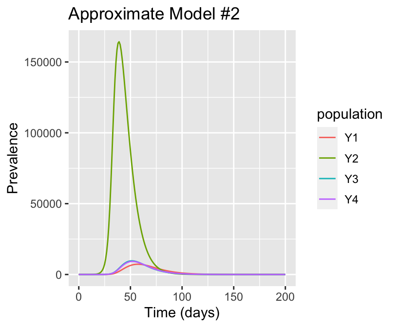

```r
sim22 %>% dplyr::select(time, Y1, Y2, Y3, Y4) %>%
  gather(key = population, value = number, Y1, Y2, Y3, Y4) %>%
  ggplot(aes(x = time, y = number, color = population, group = population)) +
  geom_line() + labs(x = "Time (days)", y = "Prevalence", title = "Approximate Model #2")
```

```r
sim4City <- seirNCity(n = 4, N = c(1e6, 1e6, 1e6, 1e6), p = c(0.95, 0.5, 0.95, 0.95), I0 = c(1, 1, 0, 0),
                      fM = matrix(c(0.998, 0.001, 0.001, 0.001, 0.025, 0.9, 0.025, 0.05,
                                    0.025, 0.025, 0.9, 0.05, 0.1, 0, 0, 0.9),
                                  nrow = 4, ncol = 4, byrow = FALSE), tf = 200)
```

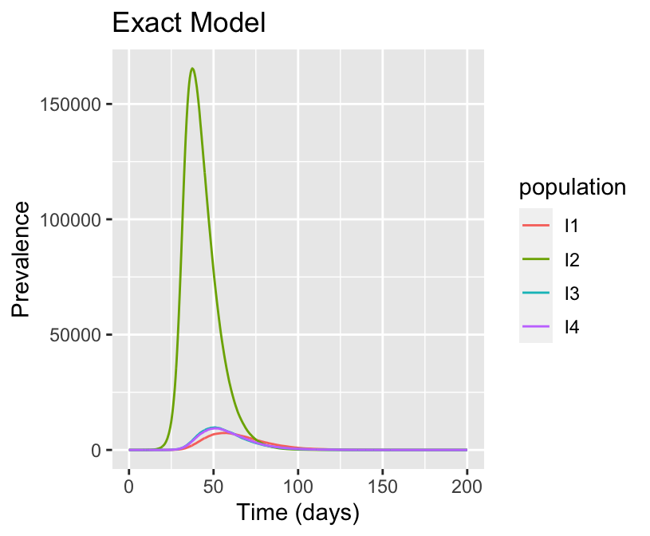

```r
sim4City %>% dplyr::select(time, I1, I2, I3, I4) %>%
  gather(key = population, value = number, I1, I2, I3, I4) %>%
  ggplot(aes(x = time, y = number, color = population, group = population)) +
  geom_line() + labs(x = "Time (days)", y = "Prevalence", title = "Exact Model")
```

Let’s calculate the average time until the peak of the epidemic in all populations in both model. This will also serve as an opportunity to compare the running times of each of the models.

```r
library(timeR)
f1 <- function(n = 4, N = c(1e6, 1e6, 1e6, 1e6), v = c(0.95, 0.5, 0.95, 0.95), Y0 = c(1, 1, 0, 0),
               fM = matrix(c(0.998, 0.001, 0.001, 0.001, 0.025, 0.9, 0.025, 0.05,
                             0.025, 0.025, 0.9, 0.05, 0.1, 0, 0, 0.9),
                           nrow = 4, ncol = 4, byrow = FALSE), tf = 200) {
  df <- nCityApprox2(n = n, N = N, v = v, Y0 = Y0, tf = tf, fM = fM)
  c(df[which.max(df$Y1), 1], df[which.max(df$Y2), 1], df[which.max(df$Y3), 1], df[which.max(df$Y4), 1])
}

f2 <- function(num = 4, N = c(1e6, 1e6, 1e6, 1e6), p = c(0.95, 0.5, 0.95, 0.95), I0 = c(1, 1, 0, 0),
               fM = matrix(c(0.998, 0.001, 0.001, 0.001, 0.025, 0.9, 0.025, 0.05,
                             0.025, 0.025, 0.9, 0.05, 0.1, 0, 0, 0.9),
                           nrow = 4, ncol = 4, byrow = FALSE), tf = 200) {
  df <- seirNCity(num = num, N = N, p = p, I0 = I0, fM = fM, tf = 200)
  c(df[which.max(df$I1), 1], df[which.max(df$I2), 1], df[which.max(df$I3), 1], df[which.max(df$I4), 1])
}

timer <- createTimer(FALSE)
n <- 1000
timer$start("Deterministic Model")
approxModel <- colMeans(do.call(rbind, purrr::rerun(n, f1())))
timer$stop("Deterministic Model")
timer$start("Stochastic Model")
test <- do.call(rbind, purrr::rerun(n, f2()))
exactModel <- colMeans(do.call(rbind, purrr::rerun(n, f2())))
timer$stop("Stochastic Model")
```

```r
data.frame("Population 1 Peak" = approxModel[1], "Population 2 Peak" = approxModel[2],
           "Population 3 Peak" = approxModel[3], "Population 4 Peak" = approxModel[4])
```

```
##   Population.1.Peak Population.2.Peak Population.3.Peak Population.4.Peak
## 1             56.89             38.89             50.89             51.89
```

```r
data.frame("Population 1 Peak" = exactModel[1], "Population 2 Peak" = exactModel[2],
           "Population 3 Peak" = exactModel[3], "Population 4 Peak" = exactModel[4])
```

```
##   Population.1.Peak Population.2.Peak Population.3.Peak Population.4.Peak
## 1          55.88283          37.70769          50.07467          50.69017
```

```r
timer
```

```
## Your Table is:
##                 event               start                 end timeElapsed comment
## 1 Deterministic Model 2020-06-18 06:36:15 2020-06-18 06:46:02         587    <NA>
## 2    Stochastic Model 2020-06-18 06:46:02 2020-06-18 07:04:20        1098    <NA>
```

Let’s have a look at a trivial 10 population example.

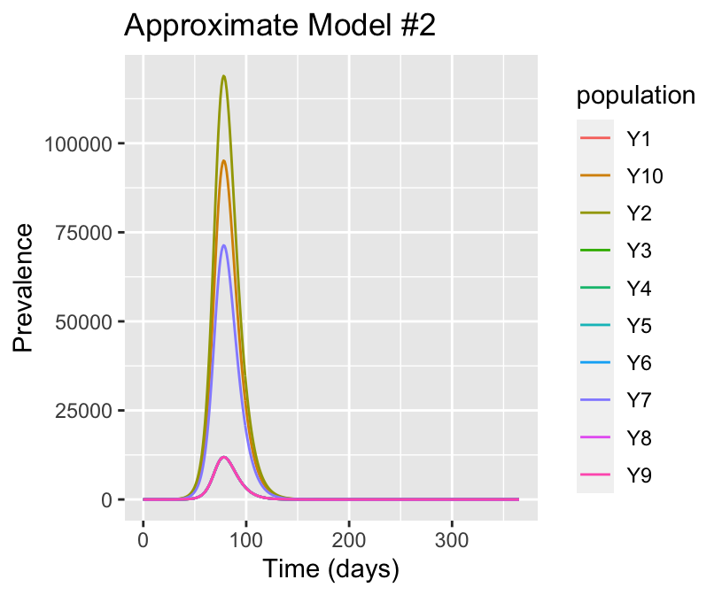

```r
sim23 <- nCityApprox2(n = 10, N = rep(1e6, 10),
                      v = c(0.95, 0.5, 0.95, 0.95, 0.95, 0.95, 0.7, 0.95, 0.95, 0.6),
                      Y0 = c(1, 1, 0, 0, 0, 0, 1, 0, 0, 0),
                      fM = matrix(rep(0.1, 100), nrow = 10, ncol = 10, byrow = FALSE), tf = 365)

sim23 %>% dplyr::select(time, Y1:Y10) %>%
  gather(key = population, value = number, Y1:Y10) %>%
  ggplot(aes(x = time, y = number, color = population, group = population)) +
  geom_line() + labs(x = "Time (days)", y = "Prevalence", title = "Approximate Model #2")
```

```r
library(timeR)
f1 <- function(n = 10, N = rep(1e6, 10), v = c(0.95, 0.5, 0.95, 0.95, 0.95, 0.95, 0.7, 0.95, 0.95, 0.6),
               Y0 = c(1, 1, 0, 0, 0, 0, 1, 0, 0, 0),
               fM = matrix(rep(0.1, 100), nrow = 10, ncol = 10, byrow = FALSE), tf = 200) {
  df <- nCityApprox2(n = n, N = N, v = v, Y0 = Y0, tf = tf, fM = fM)
  unlist(purrr::map(seq(2, 11), function(x) df[which.max(df[,x]), 1]))
}

f2 <- function(num = 10, N = rep(1e6, 10), p = c(0.95, 0.5, 0.95, 0.95, 0.95, 0.95, 0.7, 0.95, 0.95, 0.6),
               I0 = c(1, 1, 0, 0, 0, 0, 1, 0, 0, 0),
               fM = matrix(rep(0.1, 100), nrow = 10, ncol = 10, byrow = FALSE), tf = 200) {
  df <- seirNCity(num = num, N = N, p = p, I0 = I0, fM = fM, tf = tf)
  unlist(purrr::map(seq(2, 11), function(x) df[which.max(df[,x]), 1]))
}

timer <- createTimer(FALSE)
n <- 100
timer$start("Deterministic Model")
approxModel <- colMeans(do.call(rbind, purrr::rerun(n, f1())))
timer$stop("Deterministic Model")
timer$start("Stochastic Model")
test <- do.call(rbind, purrr::rerun(n, f2()))
exactModel <- colMeans(do.call(rbind, purrr::rerun(n, f2())))
timer$stop("Stochastic Model")
```

```r
timer
```

```
## Your Table is:
##                 event               start                 end timeElapsed comment
## 1 Deterministic Model 2020-06-18 07:27:36 2020-06-18 07:33:37         361    <NA>
## 2    Stochastic Model 2020-06-18 07:33:37 2020-06-18 07:40:10         393    <NA>
```

The deterministic model scales poorly with the time frame, which is attributable to the fact that each time the system simulates the deterministic SEIR model over the set of populations currently experiencing epidemics the deterministic equations are numerically solved over the entire time frame even when the time to the next epidemic is relatively soon.